# Eurofer Properties Database

## Section 1: Manufacturing & Heat Treatment

### 1.1. Composition

| Specification | Producer analysis, heat 83699/83698 (Ø100 mm/14 mm) | IMF analysis, heat 83698, 1.5 mm plate | CEA analysis, 3 heats, 5 sizes |  |
| --- | --- | --- | --- | --- |
| Cr | 8.50-9.50 | 8.87/8.82 | 9.21 | 8.68-9.04 |
| C | 0.09-0.12 | 0.12/0.11 | 0.104 | 0.092-0.117 |
| Mn | 0.20-0.60 | 0.42/0.47 | 0.502 | 0.41-0.50 |
| V | 0.15-0.25 | 0.19/0.20 | 0.204 | 0.17-0.19 |
| W | 1.0-1.2 | 1.10/1.09 | 1.148 | 1.03-1.26 |
| Ta | 0.05-0.09 | 0.14/0.13 | 0.14 | 0.10-0.15 |
| N2 | 0.015-0.045 | 0.018/0.020 | 0.0234 | 0.018-0.0226 |
| O2 | max. 0.01 | 0.0013/0.0010 | <0.001 | 0.0005-0.0011 |
| P | max. 0.005 | 0.004/0.005 | <0.04 | 0.011-0.013 |
| S | max. 0.005 | 0.003/0.004 | 0.004 | <0.003 |
| B | max. 0.001*) | <0.0005/0.001 | <0.01 | <0.001 |
| Ti | max. 0.01 | 0.008/0.005 | 0.004 | 0.001-0.005 |
| Nb | max. 0.001*) | <0.0010/0.0016 | 12 ppm | <20 ppm |
| Mo | max. 0.005*) | <0.0010/0.0010 | <8 | <20-100 |
| Ni | max. 0.005*) | <0.007/0.0200 | 214 | 400-600 |
| Cu | max. 0.005*) | 0.022/0.0016 | 35 | 30-400 |
| Al | max. 0.01*) | 0.008/0.009 | 51 | 30-40 |
| Si | max. 0.05*) | 0.07/0.04 | 430 | 300-600 |
| Co | max. 0.005*) | 0.004/0.006 | 67 | 80-200 |
| As+Sn+Sb+Zr | max. 0.05 | <0.015/0.015 |  | <65-145 |

### 1.2. Heat Treatment

For a heat treatment sequence involving initial austenitization followed by a lower temperature tempering, example stages and their effects on the microstructure of ferritic/martensitic steel are as follows:

1. **Austenitizing: 979°C for 2 hours, followed by air cooling**
   - **Purpose**: This stage is aimed at fully austenitizing the steel, converting the initial microstructure (whether ferrite, pearlite, or a mix) to austenite. This high temperature ensures the dissolution of carbides and homogenizes the alloy elements within the steel matrix.
2. **Tempering: 739°C for 4 hours, followed by air cooling**
   - **Purpose**: The second stage is significantly lower than the first and serves to temper the martensitic structure formed after the first air cooling. Tempering at this temperature typically leads to a substantial transformation within the microstructure, focusing more on enhancing toughness and ductility while reducing hardness to a controlled extent compared to higher tempering temperatures.

#### Expected Microstructure

- **Tempered Martensite**: The quick cooling after the initial austenitization forms martensite, which is hard and brittle. The subsequent tempering at 739°C is essential for modifying this martensite. At this temperature, the martensitic structure undergoes significant changes:
  - **Carbide Precipitation**: Finer and more evenly distributed carbides form during this tempering stage. These carbides are crucial for increasing the toughness and wear resistance of the steel.
  - **Relaxation of Martensite**: The brittle martensitic lattice relaxes slightly, reducing internal stresses and thus decreasing the brittleness.
- **Potential Bainitic Transformation**: Depending on the specific alloying elements and their concentrations, tempering at this lower temperature (739°C) might also facilitate the formation of lower bainite. Bainite is a plate-like microstructure that offers a beneficial combination of strength and ductility. Its formation would depend significantly on the alloy composition and the actual cooling rate post-tempering.
- **Retained Austenite Stability**: At this lower tempering temperature, any retained austenite from the first cooling is more likely to remain stable or transform into bainite rather than converting into martensite, which can add to the ductility and toughness of the final product.

The image below depicts the expected microstructure of tempered martensitic steel. It shows finely dispersed carbides within a martensitic matrix, typical for steel that has been tempered at lower temperatures.

[figure not shown]

Fig.1 - Microstructure of tempered martensitic steel. It shows finely dispersed carbides within a martensitic matrix, typical for steel that has been tempered at lower temperatures.

1. **Aging: 600°C for 5000 hours** **Long-term aging** at 600°C for 5000 hours is a specific type of annealing used primarily to understand and enhance the stability of ferritic/martensitic steels under prolonged thermal exposure. This process is particularly relevant in power generation and aerospace applications where components may experience elevated temperatures for extended periods.

##### Goals of the Annealing Process

1. **Stabilize the Microstructure**: Continuous exposure at 600°C aims to stabilize the microstructure against changes during future operational use.
2. **Optimize Mechanical Properties**: The process intends to balance ductility, toughness, and strength, making the steel suitable for long-term applications at high temperatures.

#### Expected Microstructural Changes

1. **Precipitation and Growth of Carbides**: At 600°C, you can expect the precipitation of various carbides, such as M<sub>23</sub>C<sub>6</sub> (where M can be Cr, Fe), and their growth or coalescence over the extended period. This affects the steel's hardness and tensile strength.
2. **Formation of Laves Phase**: In some ferritic/martensitic steels, especially those with high alloy content, a Fe<sub>2</sub>Mo-type Laves phase can form, which could influence creep resistance negatively by depleting the matrix of beneficial alloying elements like W and Mo.
3. **Spheroidization of Existing Carbides**: If the material has undergone previous treatments that formed pearlite or other lamellar structures, spheroidization might occur, leading to a more ductile microstructure.

#### Impact on Properties

- **Decrease in Hardness and Strength**: Due to the growth and coalescence of carbides, the material might lose some hardness and tensile strength.
- **Increase in Toughness and Ductility**: The spheroidization and stabilization processes tend to increase material ductility and fracture toughness, which are critical for components that undergo thermal cycling.
- **Potential Decrease in Creep Resistance**: The formation of Laves phases and the growth of large carbides can reduce the creep resistance, an essential factor for high-temperature applications.

### 1.3. Microstructure

[figure not shown]

Fig.2 - Orientation image maps from EBSD data of ODS-Eurofer steel austenitized at different temperatures (60×40 μm², step size 40 nm).

[figure not shown]

Fig.3 - Mean grain size dependence on austenitizing temperature.

## Section 2: Thermophysical Properties

```python
%load_ext autoreload
%autoreload 2

from Utilities_modeling_1_0 import *
from Utilities_plots_1_0 import *

excel_filename = 'Eurofer_data.xlsx'
material_name = "Eurofer"

# Temperature range and initializations
T = np.arange(300, 1000, 10)
n = len(T)
f_size = 10
legend_size = 6
m_size = 60
```

### 2.1. Density

|  | EUROFER97TempK | EUROFER97DensityKg_m_3 |
| --- | --- | --- |
| 0 | 293 | 7750 |
| 1 | 373 | 7728 |
| 2 | 473 | 7699 |
| 3 | 573 | 7666 |
| 4 | 673 | 7633 |
| 5 | 773 | 7596 |
| 6 | 873 | 7558 |

**Fitting parameters for Eurofer_density**

```
[[Model]]
    Model(<lambda>)
[[Fit Statistics]]
    # fitting method   = leastsq
    # function evals   = 13
    # data points      = 7
    # variables        = 3
    chi-square         = 1.01777725
    reduced chi-square = 0.25444431
    Akaike info crit   = -7.49802348
    Bayesian info crit = -7.66029303
    R-squared          = 0.99996549
[[Variables]]
    a: -1.1119e-04 +/- 5.9091e-06 (5.31%) (init = 1)
    b: -0.20182687 +/- 0.00693480 (3.44%) (init = 1)
    c:  7818.78692 +/- 1.86441851 (0.02%) (init = 1)
[[Correlations]] (unreported correlations are < 0.100)
    C(a, b) = -0.9901
    C(b, c) = -0.9810
    C(a, c) = +0.9482
```

**The equation for Eurofer_density is:**

$\displaystyle - 0.000111192 T^{2} - 0.201827 T + 7818.79$

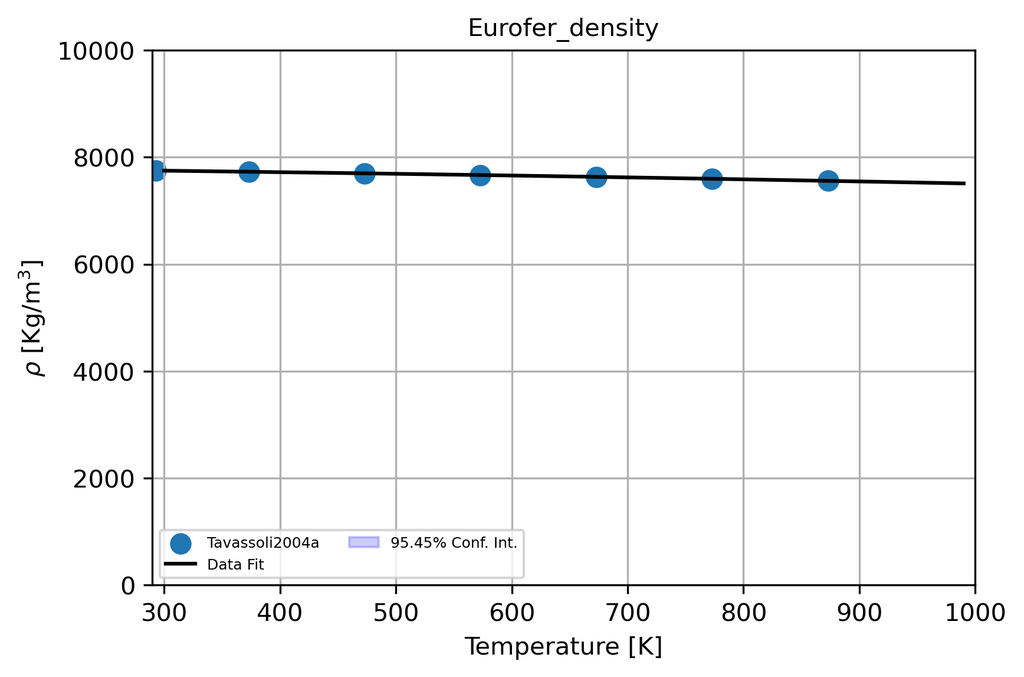

```python
# Load excel data for desired property name
material_property = "Eurofer_density"
var_names, variables = load_data(excel_filename, material_property, header_rows_list=[1, 3], num_data_rows=7)

x_label = 'Temperature [K]'
y_label = r'$\rho$ [Kg/m$^3$]'
x_lim = [290, 1000]
y_lim = [0, 10000]
data_labels = ['Tavassoli2004a']

# Concatenate and sort data for fitting
vars_x = variables[::2]
vars_y = variables[1::2]
T_data, Y_data = concatenate_and_sort(vars_x, vars_y)
x_data_list = [x for x in vars_x]
y_data_list = vars_y

# Fit the data
fit_result = get_model_fit(T_data, Y_data, material_name, material_property, fit_func='poly', fit_initials={'a': 1, 'b': 1, 'c': 1})

# Plot the data
plot_data(x_data_list, y_data_list,T, fit_result, x_label, y_label, x_lim, y_lim, data_labels, material_property,
          f_size, legend_size, m_size)
```

### 2.2. Thermal Diffusivity

|  | EUROFER97MergiaTempK | EUROFER97MergiaThermalDiffusivityCoefcm2/s |
| --- | --- | --- |
| 0 | 295.595855 | 0.081641 |
| 1 | 322.797927 | 0.080790 |
| 2 | 373.316062 | 0.077536 |
| 3 | 472.797927 | 0.075784 |
| 4 | 573.056995 | 0.070729 |
| 5 | 673.316062 | 0.064822 |
| 6 | 772.797927 | 0.058014 |
| 7 | 873.056995 | 0.050256 |

**Fitting parameters for Eurofer_diffusivity**

```
[[Model]]
    Model(<lambda>)
[[Fit Statistics]]
    # fitting method   = leastsq
    # function evals   = 13
    # data points      = 8
    # variables        = 3
    chi-square         = 2.6948e-06
    reduced chi-square = 5.3897e-07
    Akaike info crit   = -113.228942
    Bayesian info crit = -112.990617
    R-squared          = 0.99701563
[[Variables]]
    a: -5.0637e-08 +/- 8.3333e-09 (16.46%) (init = 1)
    b:  5.7279e-06 +/- 9.6212e-06 (167.97%) (init = 1)
    c:  0.08388973 +/- 0.00249931 (2.98%) (init = 1)
[[Correlations]] (unreported correlations are < 0.100)
    C(a, b) = -0.9909
    C(b, c) = -0.9831
    C(a, c) = +0.9539
```

**The equation for Eurofer_diffusivity is:**

$\displaystyle - 5.06371 \cdot 10^{-8} T^{2} + 5.72789 \cdot 10^{-6} T + 0.0838897$

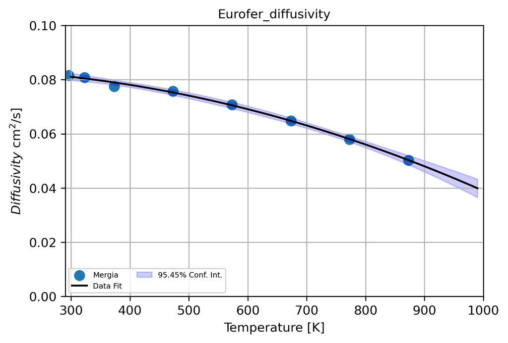

```python
material_property = "Eurofer_diffusivity"
var_names, variables = load_data(excel_filename, material_property, header_rows_list=[1, 3], num_data_rows=8)
x_label = 'Temperature [K]'
y_label = r'$Diffusivity$ cm$^2$/s]'
x_lim = [290, 1000]
y_lim = [0, 0.1]
data_labels = ['Mergia']


# Concatenate and sort data for fitting
vars_x = variables[::2]
vars_y = variables[1::2]
T_data, Y_data = concatenate_and_sort(vars_x, vars_y)
x_data_list = [x for x in vars_x]
y_data_list = vars_y

# Fit the data
fit_result = get_model_fit(T_data, Y_data, material_name, material_property, fit_func='poly', fit_initials={'a': 1, 'b': 1, 'c': 1})

# Plot the data
plot_data(x_data_list, y_data_list,T, fit_result, x_label, y_label, x_lim, y_lim, data_labels, material_property, f_size, legend_size, m_size)
```

### 2.3. Specific Heat

|  | EUROFER97MergiaTempK | EUROFER97MergiaSpecificHeatJ/kgK | EUROFER97TempK | EUROFER97SpecificHeatJ/kgK |
| --- | --- | --- | --- | --- |
| 0 | 296.103896 | 448.395379 | 293.54795 | 454.68159 |
| 1 | 322.727273 | 461.489089 | 326.42466 | 467.34914 |
| 2 | 348.051948 | 475.353017 | 373.00000 | 488.52065 |
| 3 | 373.376623 | 485.365854 | 425.05479 | 509.65287 |
| 4 | 398.051948 | 496.148909 | 474.36986 | 522.20258 |
| 5 | 423.376623 | 504.621309 | 523.68493 | 543.35445 |
| 6 | 447.402597 | 513.863928 | 573.00000 | 551.60308 |
| 7 | 472.727273 | 521.566110 | 622.31507 | 572.75495 |
| 8 | 498.051948 | 530.038511 | 671.63014 | 585.30466 |
| 9 | 522.727273 | 536.970475 | 723.68493 | 610.73796 |
| 10 | 548.051948 | 544.672657 | 773.00000 | 653.39520 |
| 11 | 572.727273 | 550.834403 | 822.31507 | 721.85889 |
| 12 | 598.051948 | 556.996149 | 871.63014 | 803.22581 |
| 13 | 622.727273 | 565.468549 | 920.94521 | 901.79702 |
| 14 | 648.051948 | 573.170732 | 973.00000 | 1026.15505 |
| 15 | 673.376623 | 583.953787 | NaN | NaN |
| 16 | 698.051948 | 597.047497 | NaN | NaN |
| 17 | 722.727273 | 611.681643 | NaN | NaN |
| 18 | 747.402597 | 628.626444 | NaN | NaN |
| 19 | 773.376623 | 655.584082 | NaN | NaN |
| 20 | 797.402597 | 687.163030 | NaN | NaN |
| 21 | 822.727273 | 721.052632 | NaN | NaN |
| 22 | 847.402597 | 764.184852 | NaN | NaN |
| 23 | 872.727273 | 801.155327 | NaN | NaN |

**Fitting parameters for Eurofer_specific_heat**

```
[[Model]]
    Model(<lambda>)
[[Fit Statistics]]
    # fitting method   = leastsq
    # function evals   = 16
    # data points      = 39
    # variables        = 4
    chi-square         = 883.943790
    reduced chi-square = 25.2555369
    Akaike info crit   = 129.712441
    Bayesian info crit = 136.366688
    R-squared          = 0.99857268
[[Variables]]
    a:  4.0223e-06 +/- 1.2721e-07 (3.16%) (init = 1)
    b: -0.00617055 +/- 2.3728e-04 (3.85%) (init = 1)
    c:  3.37274344 +/- 0.14033902 (4.16%) (init = 1)
    d: -116.692873 +/- 26.0385679 (22.31%) (init = 1)
[[Correlations]] (unreported correlations are < 0.100)
    C(a, b) = -0.9950
    C(b, c) = -0.9939
    C(c, d) = -0.9920
    C(a, c) = +0.9785
    C(b, d) = +0.9732
    C(a, d) = -0.9479
```

**The equation for Eurofer_specific_heat is:**

$\displaystyle 4.02233 \cdot 10^{-6} T^{3} - 0.00617055 T^{2} + 3.37274 T - 116.693$

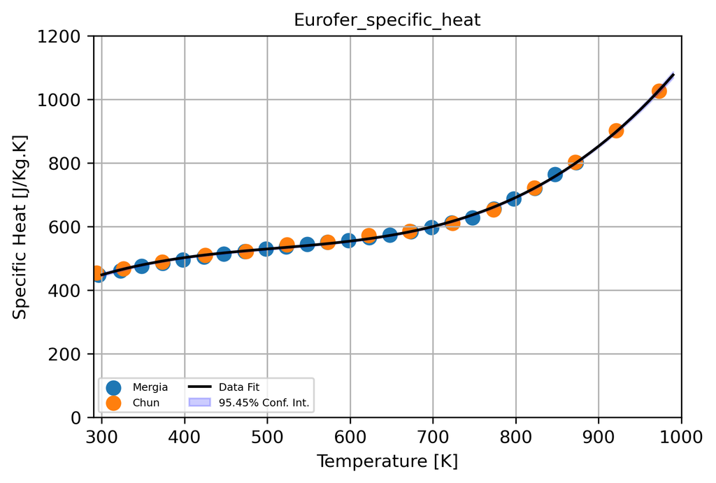

```python
material_property = "Eurofer_specific_heat"
var_names, variables = load_data(excel_filename, material_property, header_rows_list=[1, 3], num_data_rows=24)
x_label = 'Temperature [K]'
y_label = r'Specific Heat [J/Kg.K]'
x_lim = [290, 1000]
y_lim = [0, 1200]
data_labels = ['Mergia','Chun']


# Concatenate and sort data for fitting
vars_x = variables[::2]
vars_y = variables[1::2]
T_data, Y_data = concatenate_and_sort(vars_x, vars_y)
x_data_list = [x for x in vars_x]
y_data_list = vars_y

# Fit the data
fit_result = get_model_fit(T_data, Y_data, material_name, material_property, fit_func='poly', fit_initials={'a': 1, 'b': 1, 'c': 1, 'd':1})

# Plot the data
plot_data(x_data_list, y_data_list,T, fit_result, x_label, y_label, x_lim, y_lim, data_labels, material_property,
          f_size, legend_size, m_size)
```

### 2.4. Conductivity

|  | EUROFER97MergiaTempK | EUROFER97MergiaThermalConductivitykW/mK | EUROFER97TempK1 | EUROFER97ThermalConductivityW/mK |
| --- | --- | --- | --- | --- |
| 0 | 295.833333 | 28.330097 | 293.54795 | 28.15894 |
| 1 | 322.619048 | 28.932039 | 323.68493 | 28.88742 |
| 2 | 372.619048 | 29.194175 | 375.73973 | 29.74834 |
| 3 | 473.214286 | 30.669903 | 425.05479 | 30.27815 |
| 4 | 572.619048 | 30.194175 | 474.36986 | 30.34437 |
| 5 | 672.619048 | 29.330097 | 526.42466 | 30.21192 |
| 6 | 772.619048 | 29.446602 | 573.00000 | 29.94702 |
| 7 | 872.619048 | 31.174757 | 625.05479 | 29.68212 |
| 8 | NaN | NaN | 674.36986 | 29.48344 |
| 9 | NaN | NaN | 723.68493 | 29.35099 |
| 10 | NaN | NaN | 775.73973 | 29.61589 |
| 11 | NaN | NaN | 825.05479 | 30.07947 |
| 12 | NaN | NaN | 874.36986 | 31.13907 |

**Fitting parameters for Eurofer_conductivity**

```
[[Model]]
    Model(<lambda>)
[[Fit Statistics]]
    # fitting method   = leastsq
    # function evals   = 16
    # data points      = 21
    # variables        = 4
    chi-square         = 0.55241752
    reduced chi-square = 0.03249515
    Akaike info crit   = -68.3974451
    Bayesian info crit = -64.2193553
    R-squared          = 0.95674888
[[Variables]]
    a:  1.3195e-07 +/- 8.6392e-09 (6.55%) (init = 1)
    b: -2.3475e-04 +/- 1.5154e-05 (6.46%) (init = 1)
    c:  0.13326278 +/- 0.00839406 (6.30%) (init = 1)
    d:  5.87583880 +/- 1.45053551 (24.69%) (init = 1)
[[Correlations]] (unreported correlations are < 0.100)
    C(a, b) = -0.9964
    C(b, c) = -0.9954
    C(c, d) = -0.9942
    C(a, c) = +0.9839
    C(b, d) = +0.9802
    C(a, d) = -0.9613
```

**The equation for Eurofer_conductivity is:**

$\displaystyle 1.31951 \cdot 10^{-7} T^{3} - 0.000234752 T^{2} + 0.133263 T + 5.87584$

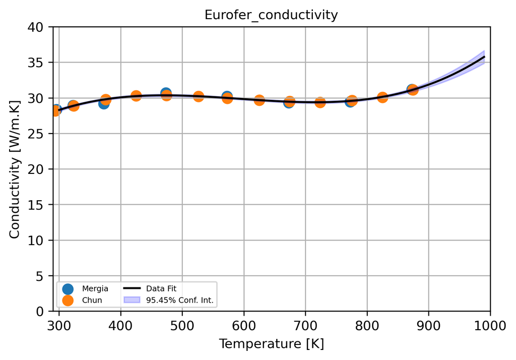

```python
material_property = "Eurofer_conductivity"
var_names, variables = load_data(excel_filename, material_property, header_rows_list=[1, 3], num_data_rows=13)
x_label ='Temperature [K]'
y_label =r'Conductivity [W/m.K]'
x_lim = [290, 1000]
y_lim = [0, 40]
data_labels = ['Mergia','Chun']



# Concatenate and sort data for fitting
vars_x = variables[::2]
vars_y = variables[1::2]
T_data, Y_data = concatenate_and_sort(vars_x, vars_y)
x_data_list = [x for x in vars_x]
y_data_list = vars_y

# Fit the data
fit_result = get_model_fit(T_data, Y_data, material_name, material_property, fit_func='poly', fit_initials={'a': 1, 'b': 1, 'c': 1, 'd':1})

# Plot the data
plot_data(x_data_list, y_data_list,T, fit_result, x_label, y_label, x_lim, y_lim, data_labels, material_property,
          f_size, legend_size, m_size)
```

### 2.5. Resistivity

|  | EUROFER97MergiaTempK | EUROFER97MergiaElectricalResistivityx108ohmm |
| --- | --- | --- |
| 0 | 303.317972 | 51.077844 |
| 1 | 327.649770 | 54.550898 |
| 2 | 344.239631 | 56.467066 |
| 3 | 365.806452 | 59.101796 |
| 4 | 396.221198 | 62.814371 |
| 5 | 423.317972 | 66.407186 |
| 6 | 450.414747 | 69.281437 |
| 7 | 467.004608 | 71.437126 |
| 8 | 497.419355 | 75.508982 |
| 9 | 523.410138 | 77.425150 |
| 10 | 545.529954 | 81.137725 |
| 11 | 577.050691 | 84.730539 |
| 12 | 601.935484 | 87.245509 |
| 13 | 657.788018 | 93.473054 |
| 14 | 682.119816 | 96.227545 |
| 15 | 708.110599 | 99.580838 |
| 16 | 734.654378 | 102.574850 |
| 17 | 763.410138 | 105.808383 |
| 18 | 783.870968 | 107.964072 |
| 19 | 817.050691 | 111.197605 |
| 20 | 850.230415 | 114.191617 |
| 21 | 883.963134 | 117.425150 |
| 22 | 924.884793 | 121.377246 |

**Fitting parameters for Eurofer_resistivity**

```
[[Model]]
    Model(<lambda>)
[[Fit Statistics]]
    # fitting method   = leastsq
    # function evals   = 16
    # data points      = 23
    # variables        = 4
    chi-square         = 1.87113879
    reduced chi-square = 0.09848099
    Akaike info crit   = -49.7057808
    Bayesian info crit = -45.1638040
    R-squared          = 0.99982324
[[Variables]]
    a: -3.2423e-08 +/- 1.2582e-08 (38.81%) (init = 1)
    b:  3.4060e-05 +/- 2.3101e-05 (67.82%) (init = 1)
    c:  0.11058275 +/- 0.01348806 (12.20%) (init = 1)
    d:  15.6365129 +/- 2.48311632 (15.88%) (init = 1)
[[Correlations]] (unreported correlations are < 0.100)
    C(a, b) = -0.9957
    C(b, c) = -0.9947
    C(c, d) = -0.9934
    C(a, c) = +0.9813
    C(b, d) = +0.9772
    C(a, d) = -0.9551
```

**The equation for Eurofer_resistivity is:**

$\displaystyle - 3.24229 \cdot 10^{-8} T^{3} + 3.40596 \cdot 10^{-5} T^{2} + 0.110583 T + 15.6365$

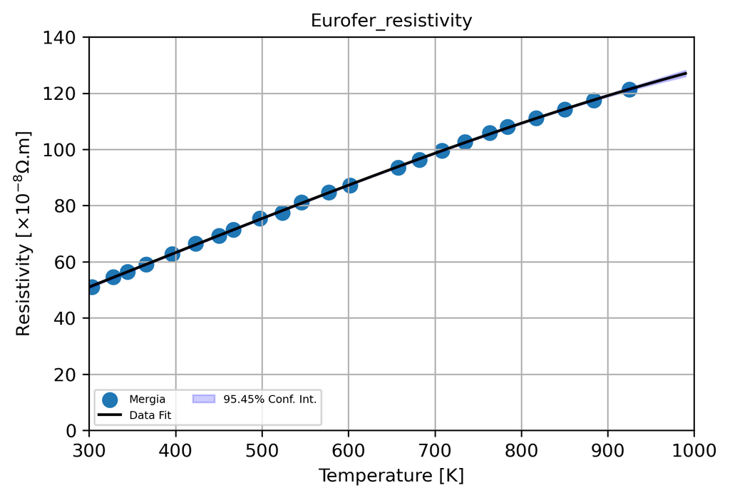

```python
material_property = "Eurofer_resistivity"
var_names, variables = load_data(excel_filename, material_property, header_rows_list=[1, 3], num_data_rows=23)
x_label='Temperature [K]'
y_label=r'Resistivity [$\times 10^{-8} \Omega$.m]'
x_lim=[300, 1000]
y_lim=[0, 140]
data_labels = ['Mergia']

# Concatenate and sort data for fitting
vars_x = variables[::2]
vars_y = variables[1::2]
T_data, Y_data = concatenate_and_sort(vars_x, vars_y)
x_data_list = [x for x in vars_x]
y_data_list = vars_y

# Fit the data
fit_result = get_model_fit(T_data, Y_data, material_name, material_property, fit_func='poly', fit_initials={'a': 1, 'b': 1, 'c': 1, 'd':1})

# Plot the data
plot_data(x_data_list, y_data_list,T, fit_result, x_label, y_label, x_lim, y_lim, data_labels, material_property,
          f_size, legend_size, m_size)
```

### 2.6. CTE

|  | EUROFER97TempC | EUROFER97CoefficientofThermalExpansion |
| --- | --- | --- |
| 0 | 100 | 10.689873 |
| 1 | 200 | 11.044304 |
| 2 | 300 | 11.386076 |
| 3 | 400 | 11.696203 |
| 4 | 500 | 11.987342 |
| 5 | 600 | 12.246835 |
| 6 | 700 | 12.487342 |

**Fitting parameters for Eurofer_CTE**

```
[[Model]]
    Model(<lambda>)
[[Fit Statistics]]
    # fitting method   = leastsq
    # function evals   = 16
    # data points      = 7
    # variables        = 4
    chi-square         = 2.5751e-05
    reduced chi-square = 8.5838e-06
    Akaike info crit   = -79.5905308
    Bayesian info crit = -79.8068902
    R-squared          = 0.99998983
[[Variables]]
    a: -1.7581e-10 +/- 1.9935e-10 (113.39%) (init = 1)
    b: -1.0021e-06 +/- 2.4134e-07 (24.08%) (init = 1)
    c:  0.00389793 +/- 8.5819e-05 (2.20%) (init = 1)
    d:  10.3092224 +/- 0.00850583 (0.08%) (init = 1)
[[Correlations]] (unreported correlations are < 0.100)
    C(a, b) = -0.9912
    C(b, c) = -0.9835
    C(c, d) = -0.9547
    C(a, c) = +0.9524
    C(b, d) = +0.8960
    C(a, d) = -0.8437
```

**The equation for Eurofer_CTE is:**

$\displaystyle - 1.75809 \cdot 10^{-10} T^{3} - 1.00211 \cdot 10^{-6} T^{2} + 0.00389793 T + 10.3092$

[figure not shown]

```python
material_property = "Eurofer_CTE"
var_names, variables = load_data(excel_filename, material_property, header_rows_list=[1, 3], num_data_rows=7)

x_label='Temperature [K]'
y_label=r'CTE [$10^{-6}$/K]'
x_lim=[300, 1000]
y_lim=[0, 14]
data_labels = ['Chun']


# Concatenate and sort data for fitting
vars_x = variables[::2]
vars_y = variables[1::2]
T_data, Y_data = concatenate_and_sort(vars_x, vars_y)
x_data_list = [x for x in vars_x]
y_data_list = vars_y

# Fit the data
fit_result = get_model_fit(T_data, Y_data, material_name, material_property, fit_func='poly', fit_initials={'a': 1, 'b': 1, 'c': 1, 'd':1})

# Plot the data
plot_data(x_data_list, y_data_list,T, fit_result, x_label, y_label, x_lim, y_lim, data_labels, material_property,
          f_size, legend_size, m_size)
```

### 2.7. Emissivity

|  | EUROFER97AsrolledTempK | EUROFER97AsrolledHemisphericalEmissivity | EUROFER97PolishedTempK1 | EUROFER97PolishedHemisphericalEmissivity1 | EUROFER97polishedTempK2 | EUROFER97polishedNormalEmissivity |
| --- | --- | --- | --- | --- | --- | --- |
| 0 | 473.100872 | 0.180080 | 430.136986 | 0.116901 | 423 | 0.083535 |
| 1 | 573.225405 | 0.214688 | 524.283935 | 0.128974 | 523 | 0.100909 |
| 2 | 672.976339 | 0.245272 | 624.034869 | 0.142656 | 623 | 0.120303 |
| 3 | 772.727273 | 0.273843 | 724.906600 | 0.156338 | 723 | 0.140707 |
| 4 | 872.851806 | 0.302012 | 820.921544 | 0.176459 | 823 | 0.162929 |

**Fitting parameters for Eurofer_emissivity**

```
[[Model]]
    Model(<lambda>)
[[Fit Statistics]]
    # fitting method   = leastsq
    # function evals   = 9
    # data points      = 10
    # variables        = 3
    chi-square         = 0.01976794
    reduced chi-square = 0.00282399
    Akaike info crit   = -56.2627905
    Bayesian info crit = -55.3550352
    R-squared          = 0.44822691
[[Variables]]
    a:  2.7139e-07 +/- 9.5511e-07 (351.94%) (init = 1)
    b: -7.2830e-05 +/- 0.00124698 (1712.17%) (init = 1)
    c:  0.12122007 +/- 0.39199643 (323.38%) (init = 1)
[[Correlations]] (unreported correlations are < 0.100)
    C(a, b) = -0.9955
    C(b, c) = -0.9939
    C(a, c) = +0.9797
```

**The equation for Eurofer_emissivity is:**

$\displaystyle 2.71387 \cdot 10^{-7} T^{2} - 7.28305 \cdot 10^{-5} T + 0.12122$

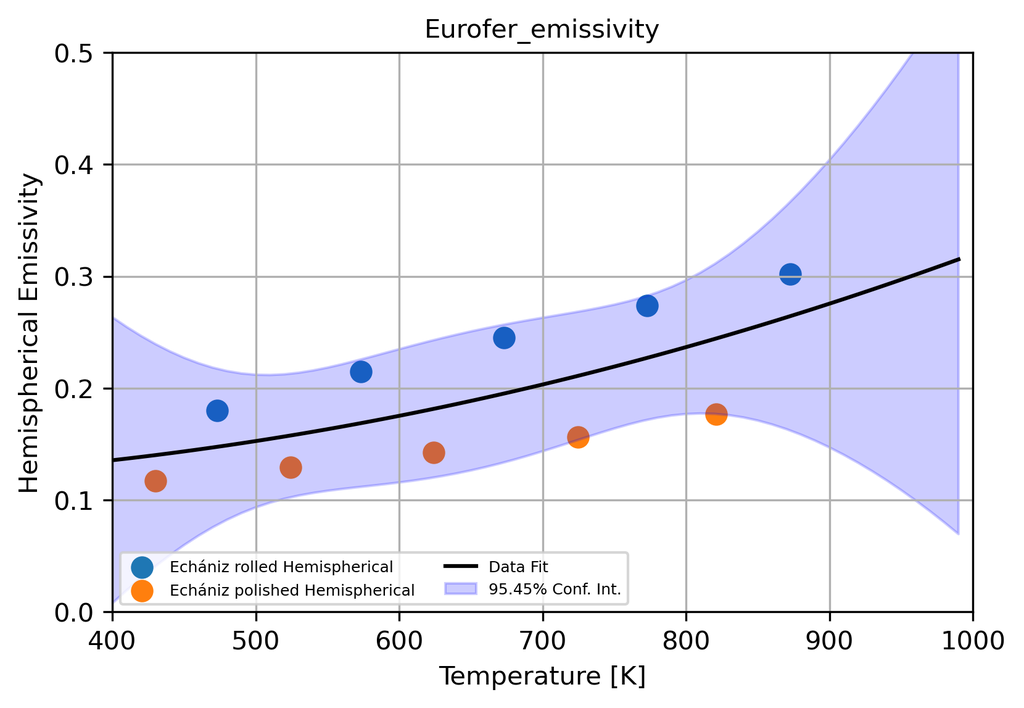

```python
material_property = "Eurofer_emissivity"
var_names, variables = load_data(excel_filename, material_property, header_rows_list=[1, 3], num_data_rows=5)
x_label = 'Temperature [K]'
y_label = r'Hemispherical Emissivity'
x_lim=[400, 1000]
y_lim=[0, 0.5]
data_labels = ['Echániz rolled Hemispherical','Echániz polished Hemispherical']

# Concatenate and sort data for fitting
vars_x = variables[:4:2]
vars_y = variables[1:4:2]
T_data, Y_data = concatenate_and_sort(vars_x, vars_y)
x_data_list = [x for x in vars_x]
y_data_list = vars_y

# Fit the data
fit_result = get_model_fit(T_data, Y_data, material_name, material_property, fit_func='poly', fit_initials={'a': 1, 'b': 1, 'c': 1})

# Plot the data
plot_data(x_data_list, y_data_list,T, fit_result, x_label, y_label, x_lim, y_lim, data_labels, material_property,
          f_size, legend_size, m_size)
```

|  | EUROFER97AsrolledTempK | EUROFER97AsrolledHemisphericalEmissivity | EUROFER97PolishedTempK1 | EUROFER97PolishedHemisphericalEmissivity1 | EUROFER97polishedTempK2 | EUROFER97polishedNormalEmissivity |
| --- | --- | --- | --- | --- | --- | --- |
| 0 | 473.100872 | 0.180080 | 430.136986 | 0.116901 | 423 | 0.083535 |
| 1 | 573.225405 | 0.214688 | 524.283935 | 0.128974 | 523 | 0.100909 |
| 2 | 672.976339 | 0.245272 | 624.034869 | 0.142656 | 623 | 0.120303 |
| 3 | 772.727273 | 0.273843 | 724.906600 | 0.156338 | 723 | 0.140707 |
| 4 | 872.851806 | 0.302012 | 820.921544 | 0.176459 | 823 | 0.162929 |

**Fitting parameters for Eurofer_emissivity**

```
[[Model]]
    Model(<lambda>)
[[Fit Statistics]]
    # fitting method   = leastsq
    # function evals   = 13
    # data points      = 5
    # variables        = 3
    chi-square         = 5.1307e-08
    reduced chi-square = 2.5653e-08
    Akaike info crit   = -85.9744103
    Bayesian info crit = -87.1460965
[[Variables]]
    a:  7.6479e-08 +/- 4.2806e-09 (5.60%) (init = 1)
    b:  1.0329e-04 +/- 5.3577e-06 (5.19%) (init = 1)
    c:  0.02611194 +/- 0.00160870 (6.16%) (init = 1)
[[Correlations]] (unreported correlations are < 0.100)
    C(a, b) = -0.9955
    C(b, c) = -0.9937
    C(a, c) = +0.9796
```

**The equation for Eurofer_emissivity is:**

$\displaystyle 7.64791 \cdot 10^{-8} T^{2} + 0.000103293 T + 0.0261119$

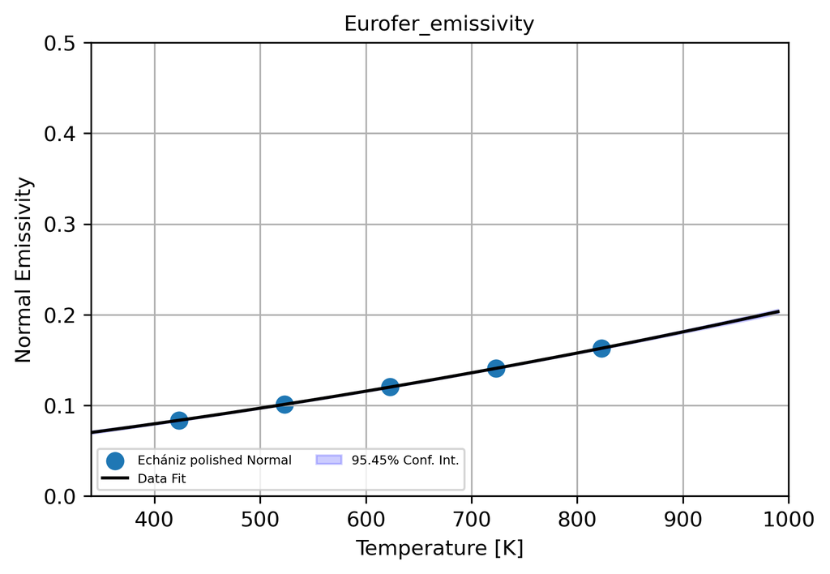

```python
material_property = "Eurofer_emissivity"
var_names, variables = load_data(excel_filename, material_property, header_rows_list=[1, 3], num_data_rows=5)
x_label = 'Temperature [K]'
y_label = r'Normal Emissivity'
x_lim=[340, 1000]
y_lim=[0, 0.5]
data_labels = ['Echániz polished Normal']

vars_x = variables[::2]
vars_y = variables[1::2]

# Extract only the third element from vars_x and vars_y

# Creating lists with only the first column
x_data_list = [vars_x[2]]
y_data_list = [vars_y[2]]

# Fit the data
fit_result1 = get_model_fit(x_data_list, y_data_list, material_name, material_property, fit_func='poly', fit_initials={'a': 1, 'b': 1, 'c': 1})

# Plot the data
plot_data(x_data_list, y_data_list,T, fit_result1, x_label, y_label, x_lim, y_lim, data_labels, material_property,
          f_size, legend_size, m_size)
```

### 2.8. Elastic

|  | EuroferETempC | EuroferEElasticModulusGpa |
| --- | --- | --- |
| 0 | 17.541148 | 33.767998 |
| 1 | 147.824743 | 32.228318 |
| 2 | 297.735878 | 36.684440 |
| 3 | 447.708832 | 40.214564 |
| 4 | 498.245885 | 33.211627 |
| 5 | 548.535662 | 29.912681 |
| 6 | 599.165443 | 21.520748 |
| 7 | 648.187930 | 20.538083 |
| 8 | 698.817711 | 12.146150 |

**Fitting parameters for Eurofer_elastic**

```
[[Model]]
    Model(<lambda>)
[[Fit Statistics]]
    # fitting method   = leastsq
    # function evals   = 16
    # data points      = 9
    # variables        = 4
    chi-square         = 42.7707338
    reduced chi-square = 8.55414676
    Akaike info crit   = 22.0276655
    Bayesian info crit = 22.8165638
    R-squared          = 0.93400315
[[Variables]]
    a: -2.8272e-07 +/- 1.2740e-07 (45.06%) (init = 1)
    b:  1.7263e-04 +/- 1.4258e-04 (82.59%) (init = 1)
    c: -0.01446073 +/- 0.04426019 (306.07%) (init = 1)
    d:  33.2221902 +/- 3.38121354 (10.18%) (init = 1)
[[Correlations]] (unreported correlations are < 0.100)
    C(a, b) = -0.9857
    C(b, c) = -0.9675
    C(a, c) = +0.9147
    C(c, d) = -0.7680
    C(b, d) = +0.6280
    C(a, d) = -0.5440
```

**The equation for Eurofer_elastic is:**

$\displaystyle - 2.82717 \cdot 10^{-7} T^{3} + 0.000172633 T^{2} - 0.0144607 T + 33.2222$

[figure not shown]

```python
material_property = "Eurofer_elastic"
var_names, variables = load_data(excel_filename, material_property, header_rows_list=[1, 3], num_data_rows=9)
x_label = 'Temperature [K]'
y_label = 'Elastic Modulus [GPa]'
x_lim=[300, 1000]
y_lim=[0, 50]
data_labels = ['Tavassoli2002']

# Concatenate and sort data for fitting
vars_x = variables[::2]
vars_y = variables[1::2]
T_data, Y_data = concatenate_and_sort(vars_x, vars_y)
x_data_list = [x for x in vars_x]
y_data_list = vars_y

# Fit the data
fit_result = get_model_fit(T_data, Y_data, material_name, material_property, fit_func='poly', fit_initials={'a': 1, 'b': 1, 'c': 1, 'd':1})

# Plot the data
plot_data(x_data_list, y_data_list,T, fit_result, x_label, y_label, x_lim, y_lim, data_labels, material_property,
          f_size, legend_size, m_size)
```

|  | Eurofer97Heat993391_1040CTemperingTempC | Eurofer97Heat993391_1040CHardness | Eurofer97Heat993402_1040CTemperingTempC1 | Eurofer97Heat993402_1040CHardness1 | Eurofer97Heat993391_980CTemperingTempC2 | Eurofer97Heat993391_980CHardness2 | Eurofer97Heat993402_980CTemperingTempC3 | Eurofer97Heat993402_980CHardness3 |
| --- | --- | --- | --- | --- | --- | --- | --- | --- |
| 0 | 20 | 410.294118 | 20 | 410.294118 | 20.0 | 409.637255 | 20.0 | 420.225490 |
| 1 | 650 | 310.539216 | 650 | 309.803922 | 650.0 | 305.166667 | 650.0 | 300.225490 |
| 2 | 700 | 264.705882 | 700 | 260.049020 | 700.0 | 264.578431 | 700.0 | 255.049020 |
| 3 | 725 | 237.745098 | 750 | 204.901961 | 750.0 | 214.460784 | 750.0 | 210.225490 |
| 4 | 775 | 204.656863 | 800 | 195.098039 | 800.0 | 199.990196 | 800.0 | 199.990196 |
| 5 | 825 | 234.803922 | 825 | 179.656863 | 825.0 | 225.049020 | 825.0 | 202.813725 |
| 6 | 850 | 299.509804 | 850 | 364.705882 | 850.0 | 389.872549 | 850.0 | 394.813725 |
| 7 | 950 | 410.294118 | 950 | 414.950980 | 900.0 | 405.401961 | 900.0 | 410.343137 |
| 8 | 1000 | 415.196078 | 1000 | 419.852941 | NaN | NaN | NaN | NaN |
| 9 | 1050 | 410.539216 | 1050 | 417.156863 | NaN | NaN | NaN | NaN |
| 10 | 1100 | 405.147059 | 1100 | 414.705882 | NaN | NaN | NaN | NaN |
| 11 | 1150 | 390.196078 | 1150 | 394.852941 | NaN | NaN | NaN | NaN |

**Fitting parameters for Eurofer_hardness**

```
[[Model]]
    Model(<lambda>)
[[Fit Statistics]]
    # fitting method   = leastsq
    # function evals   = 16
    # data points      = 40
    # variables        = 4
    chi-square         = 138289.394
    reduced chi-square = 3841.37205
    Akaike info crit   = 333.928975
    Bayesian info crit = 340.684493
    R-squared          = 0.55200356
[[Variables]]
    a: -4.9337e-07 +/- 5.8121e-07 (117.80%) (init = 1)
    b:  0.00150852 +/- 0.00107996 (71.59%) (init = 1)
    c: -1.07892521 +/- 0.50908476 (47.18%) (init = 1)
    d:  435.389761 +/- 34.5808768 (7.94%) (init = 1)
[[Correlations]] (unreported correlations are < 0.100)
    C(a, b) = -0.9965
    C(b, c) = -0.9913
    C(a, c) = +0.9784
    C(c, d) = -0.4862
    C(b, d) = +0.3893
    C(a, d) = -0.3519
```

**The equation for Eurofer_hardness is:**

$\displaystyle - 4.93373 \cdot 10^{-7} T^{3} + 0.00150852 T^{2} - 1.07893 T + 435.39$

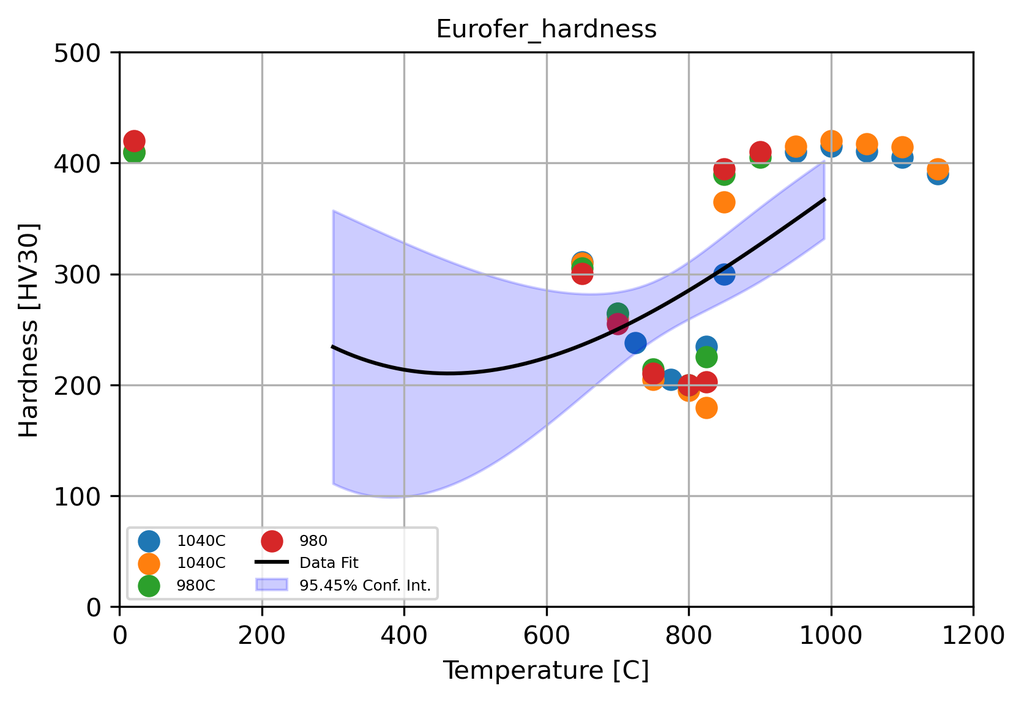

```python
material_property = "Eurofer_hardness"
var_names, variables = load_data(excel_filename, material_property, header_rows_list=[1, 3], num_data_rows=12)
x_label = 'Temperature [C]'
y_label = 'Hardness [HV30]'
x_lim=[0, 1200]
y_lim=[0, 500]
data_labels = ['1040C','1040C','980C','980']

# Concatenate and sort data for fitting
vars_x = variables[::2]
vars_y = variables[1::2]
T_data, Y_data = concatenate_and_sort(vars_x, vars_y)
x_data_list = [x for x in vars_x]
y_data_list = vars_y

# Fit the data
fit_result = get_model_fit(T_data, Y_data, material_name, material_property, fit_func='poly', fit_initials={'a':1, 'b':1, 'c':1, 'd':1})

# Plot the data
plot_data(x_data_list, y_data_list,T, fit_result, x_label, y_label, x_lim, y_lim, data_labels, material_property,
          f_size, legend_size, m_size)
```

```python
material_property = "Eurofer_strength"
var_names, variables = load_data(excel_filename, material_property, header_rows_list=[1, 3], num_data_rows=15)
x_label = 'Temperature [K]'
y_label = 'Yield Strength [MPa]'
x_lim=[0, 1200]
y_lim=[0, 800]
data_labels = ['Chun', 'Aiello']
m_size=20
# Concatenate and sort data for fitting

vars_x = (variables[10], variables[12])
vars_y = (variables[11], variables[13])

Fit the data
T_data, Y_data = concatenate_and_sort(vars_x, vars_y)
x_data_list = [x for x in vars_x]
y_data_list = vars_y

T_data = variables[10]
Y_data = variables[11]
fit_result = get_model_fit(T_data, Y_data, material_name, material_property, fit_func='poly', fit_initials={'a':1, 'b':1, 'c':1, 'd':1})

# Plot the data
plot_data(x_data_list, y_data_list,T, fit_result, x_label, y_label, x_lim, y_lim, data_labels, material_property,
          f_size, legend_size, m_size)
```

[output not shown]

```python
material_property = "Eurofer_ductility"
var_names, variables = load_data(excel_filename, material_property, header_rows_list=[1, 3], num_data_rows=15, room_temp=293)
```

```python
# Temperature range and initializations
T = np.arange(0, 800, 10)
n = len(T)

# Concatenate and sort data for fitting
vars_x = variables[::2]
vars_y = variables[1::2]

T, k = concatenate_and_sort(vars_x, vars_y)

x_data_list = [x for x in vars_x]
y_data_list = vars_y
data_labels = ['Chun', 'Van der Schaaf', 'Van der Schaaf', 'Van der Schaaf', 'Van der Schaaf', 'Van der Schaaf', 'Van der Schaaf']

fit_result = get_model_fit_and_print_it(T, k, fit_func='poly', fit_fun_args_and_initials={'a':1, 'b':1, 'c':1, 'd':1}, material_name=material_name, property_name=material_property, eq_digits=6, print_bool=True)

custom_multi_plot(x_data_list, y_data_list,
                  x_label='Temperature [K]', y_label=r'Specific Heat [J/Kg.K]', title=material_property + " of " + material_name,
                  scale='linear', font_size=fsize, xlim=[0, 800], ylim=[0, 35],
                  grid=True, legend=True, data_labels=data_labels, fit_labels=None,
                  data_colors=data_colors, fit_colors=None, data_marker_sizes=data_marker_sizes,
                  fit_line_widths=[2], x_label_font_size=fsize, y_label_font_size=fsize, title_font_size=fsize,
                  legend_font_size=fsize, legend_loc='lower left', legend_num_cols=2)
#
plot_fit_and_conf(T, fit_result, sigma=2, legend=True, legend_font_size=fsize, legend_loc='lower left', legend_num_cols=2,
                  fit_line_color='red', pred_int_fill_color='grey', conf_int_fill_color='blue')
```

[output not shown]

```python
material_property = "Eurofer_toughness"
var_names, variables = load_data(excel_filename, material_property, header_rows_list=[1, 3], num_data_rows=23, room_temp=293)
```

```python
# Temperature range and initializations
T = np.arange(-200, 500, 10)
n = len(T)

# Concatenate and sort data for fitting
vars_x = variables[::2]
vars_y = variables[1::2]

T, k = concatenate_and_sort(vars_x, vars_y)

x_data_list = [x for x in vars_x]
y_data_list = vars_y
data_colors = ['green', 'red', 'magenta', 'blue', 'cyan', 'black', 'orange', 'purple', ]
data_marker_sizes = [msize] * len(x_data_list)
data_labels = ['Tavassoli', 'Tavassoli', '3Lindau', '3Lindau', '3Lindau']

fit_result = get_model_fit_and_print_it(T, k, fit_func='poly', fit_fun_args_and_initials={'a':1, 'b':1, 'c':1, 'd':1}, material_name=material_name, property_name=material_property, eq_digits=6, print_bool=True)

custom_multi_plot(x_data_list, y_data_list,
                  x_label='Temperature [K]', y_label=r'Specific Heat [J/Kg.K]', title=material_property + " of " + material_name,
                  scale='linear', font_size=fsize, xlim=[-200, 500], ylim=[0, 350],
                  grid=True, legend=True, data_labels=data_labels, fit_labels=None,
                  data_colors=data_colors, fit_colors=None, data_marker_sizes=data_marker_sizes,
                  fit_line_widths=[2], x_label_font_size=fsize, y_label_font_size=fsize, title_font_size=fsize,
                  legend_font_size=fsize, legend_loc='lower left', legend_num_cols=2)
#
plot_fit_and_conf(T, fit_result, sigma=2, legend=True, legend_font_size=fsize, legend_loc='lower left', legend_num_cols=2,
                  fit_line_color='red', pred_int_fill_color='grey', conf_int_fill_color='blue')
```

[output not shown]

```python
material_property = "Eurofer_creep"
var_names, variables = load_data(excel_filename, material_property, header_rows_list=[1, 3], num_data_rows=10, room_temp=293)
```

```python
# Temperature range and initializations
T = np.arange(10, 300000, 10)
n = len(T)

# Concatenate and sort data for fitting
vars_x = variables[::2]
vars_y = variables[1::2]

T, k = concatenate_and_sort(vars_x, vars_y)

x_data_list = [x for x in vars_x]
y_data_list = vars_y
data_colors = ['green', 'red', 'magenta', 'blue', 'cyan', 'black', 'orange', 'purple', ]
data_marker_sizes = [msize] * len(x_data_list)
data_labels = ['Aiello', 'Aiello', 'Aiello', 'Aiello', 'Gaganidze']

fit_result = get_model_fit_and_print_it(T, k, fit_func='poly', fit_fun_args_and_initials={'a':1, 'b':1, 'c':1, 'd':1}, material_name=material_name, property_name=material_property, eq_digits=6, print_bool=True)

custom_multi_plot(x_data_list, y_data_list,
                  x_label='Temperature [K]', y_label=r'Specific Heat [J/Kg.K]', title=material_property + " of " + material_name,
                  scale='linear', font_size=fsize, xlim=[10, 300000], ylim=[0, 300],
                  grid=True, legend=True, data_labels=data_labels, fit_labels=None,
                  data_colors=data_colors, fit_colors=None, data_marker_sizes=data_marker_sizes,
                  fit_line_widths=[2], x_label_font_size=fsize, y_label_font_size=fsize, title_font_size=fsize,
                  legend_font_size=fsize, legend_loc='lower left', legend_num_cols=2)
#
plot_fit_and_conf(T, fit_result, sigma=2, legend=True, legend_font_size=fsize, legend_loc='lower left', legend_num_cols=2,
                  fit_line_color='red', pred_int_fill_color='grey', conf_int_fill_color='blue')
```

[output not shown]

```python
material_property = "Eurofer_fatigue"
var_names, variables = load_data(excel_filename, material_property, header_rows_list=[1, 3], num_data_rows=31, room_temp=293)
```

```python
# Temperature range and initializations
T = np.arange(10, 1000000, 10)
n = len(T)

# Concatenate and sort data for fitting
vars_x = variables[::2]
vars_y = variables[1::2]

T, k = concatenate_and_sort(vars_x, vars_y)

x_data_list = [x for x in vars_x]
y_data_list = vars_y
data_colors = ['green', 'red', 'magenta', 'blue', 'cyan', 'black', 'orange', 'purple', ]
data_marker_sizes = [msize] * len(x_data_list)
data_labels = ['Aiello', 'Aiello', 'Roldán', 'Roldán', 'Roldán', 'Gaganidze', 'Gaganidze']

fit_result = get_model_fit_and_print_it(T, k, fit_func='poly', fit_fun_args_and_initials={'a':1, 'b':1, 'c':1, 'd':1}, material_name=material_name, property_name=material_property, eq_digits=6, print_bool=True)

custom_multi_plot(x_data_list, y_data_list,
                  x_label='Temperature [K]', y_label=r'Specific Heat [J/Kg.K]', title=material_property + " of " + material_name,
                  scale='linear', font_size=fsize, xlim=[10, 1000000], ylim=[0, 2],
                  grid=True, legend=True, data_labels=data_labels, fit_labels=None,
                  data_colors=data_colors, fit_colors=None, data_marker_sizes=data_marker_sizes,
                  fit_line_widths=[2], x_label_font_size=fsize, y_label_font_size=fsize, title_font_size=fsize,
                  legend_font_size=fsize, legend_loc='lower left', legend_num_cols=2)
#
plot_fit_and_conf(T, fit_result, sigma=2, legend=True, legend_font_size=fsize, legend_loc='lower left', legend_num_cols=2,
                  fit_line_color='red', pred_int_fill_color='grey', conf_int_fill_color='blue')
```

[output not shown]